# DATA ANALYSIS OF US GUN DATA IN DIFFERENT STATES

This analysis would focus on the number of guns sold to the public. The `gun_data.xlsx` also contains information on private gun sales, gun rentals, pre-pawn, return to seller. However, we won’t be looking at these columns for this analysis because of the vast amount of missing data. The amount of missing data is more than half the entire length of the column.

The `US census data` is a CSV file that contains the population census for each state. There are rows for 2010 population, 2016 population, per capital income, median income and percentage increase in population. Write ups that are not relevant to our analysis are at the base of the file. This would be dropped.

The US census data contains lots of symbols and notations. Extensive data cleaning would be done to rid off these symbols.

The following resources were consulted during the analysis: The pandas API, matplotlip API, numpy API, stackoverflow, geeksforgeeks.

### QUESTIONS ANSWERED DURING ANALYSIS

This data analysis would answer the following questions:

- What are the top five states with high gun sales?
- What are the bottom five states with the least gun sales?
- What is the likely hood of buying a gun if employed?
- What census data is associated with high census per capital?
- Which state have had the highest growth in gun registration?
- What is the overall trend of gun purchases?
- How has the population increased over the years?

```python
#### import python libraries
import pandas as pd
import numpy as np
import matplotlib.pyplot as plt
import seaborn as sns
```

```python
#### read data for analysis
df_gun = pd.read_excel('gun_data.xlsx')
df_census = pd.read_csv('us_census_data.csv')
```

# Assessing the data

```python
#### Visualizing the gun data set
df_gun.head()
```

|  | month | state | permit | permit_recheck | handgun | long_gun | other | multiple | admin | prepawn_handgun | ... | returned_other | rentals_handgun | rentals_long_gun | private_sale_handgun | private_sale_long_gun | private_sale_other | return_to_seller_handgun | return_to_seller_long_gun | return_to_seller_other | totals |
| --- | --- | --- | --- | --- | --- | --- | --- | --- | --- | --- | --- | --- | --- | --- | --- | --- | --- | --- | --- | --- | --- |
| 0 | 2017-09 | Alabama | 16717.0 | 0.0 | 5734.0 | 6320.0 | 221.0 | 317 | 0.0 | 15.0 | ... | 0.0 | 0.0 | 0.0 | 9.0 | 16.0 | 3.0 | 0.0 | 0.0 | 3.0 | 32019 |
| 1 | 2017-09 | Alaska | 209.0 | 2.0 | 2320.0 | 2930.0 | 219.0 | 160 | 0.0 | 5.0 | ... | 0.0 | 0.0 | 0.0 | 17.0 | 24.0 | 1.0 | 0.0 | 0.0 | 0.0 | 6303 |
| 2 | 2017-09 | Arizona | 5069.0 | 382.0 | 11063.0 | 7946.0 | 920.0 | 631 | 0.0 | 13.0 | ... | 0.0 | 0.0 | 0.0 | 38.0 | 12.0 | 2.0 | 0.0 | 0.0 | 0.0 | 28394 |
| 3 | 2017-09 | Arkansas | 2935.0 | 632.0 | 4347.0 | 6063.0 | 165.0 | 366 | 51.0 | 12.0 | ... | 0.0 | 0.0 | 0.0 | 13.0 | 23.0 | 0.0 | 0.0 | 2.0 | 1.0 | 17747 |
| 4 | 2017-09 | California | 57839.0 | 0.0 | 37165.0 | 24581.0 | 2984.0 | 0 | 0.0 | 0.0 | ... | 0.0 | 0.0 | 0.0 | 0.0 | 0.0 | 0.0 | 0.0 | 0.0 | 0.0 | 123506 |

5 rows × 27 columns

```python
#### Visualizing the US census dataset
df_census.head()
```

|  | Fact | Fact Note | Alabama | Alaska | Arizona | Arkansas | California | Colorado | Connecticut | Delaware | ... | South Dakota | Tennessee | Texas | Utah | Vermont | Virginia | Washington | West Virginia | Wisconsin | Wyoming |
| --- | --- | --- | --- | --- | --- | --- | --- | --- | --- | --- | --- | --- | --- | --- | --- | --- | --- | --- | --- | --- | --- |
| 0 | Population estimates, July 1, 2016, (V2016) | NaN | 4,863,300 | 741,894 | 6,931,071 | 2,988,248 | 39,250,017 | 5,540,545 | 3,576,452 | 952,065 | ... | 865454 | 6651194 | 27,862,596 | 3,051,217 | 624,594 | 8,411,808 | 7,288,000 | 1,831,102 | 5,778,708 | 585,501 |
| 1 | Population estimates base, April 1, 2010, (V2... | NaN | 4,780,131 | 710,249 | 6,392,301 | 2,916,025 | 37,254,522 | 5,029,324 | 3,574,114 | 897,936 | ... | 814195 | 6346298 | 25,146,100 | 2,763,888 | 625,741 | 8,001,041 | 6,724,545 | 1,853,011 | 5,687,289 | 563,767 |
| 2 | Population, percent change - April 1, 2010 (es... | NaN | 1.70% | 4.50% | 8.40% | 2.50% | 5.40% | 10.20% | 0.10% | 6.00% | ... | 0.063 | 0.048 | 10.80% | 10.40% | -0.20% | 5.10% | 8.40% | -1.20% | 1.60% | 3.90% |
| 3 | Population, Census, April 1, 2010 | NaN | 4,779,736 | 710,231 | 6,392,017 | 2,915,918 | 37,253,956 | 5,029,196 | 3,574,097 | 897,934 | ... | 814180 | 6346105 | 25,145,561 | 2,763,885 | 625,741 | 8,001,024 | 6,724,540 | 1,852,994 | 5,686,986 | 563,626 |
| 4 | Persons under 5 years, percent, July 1, 2016, ... | NaN | 6.00% | 7.30% | 6.30% | 6.40% | 6.30% | 6.10% | 5.20% | 5.80% | ... | 0.071 | 0.061 | 7.20% | 8.30% | 4.90% | 6.10% | 6.20% | 5.50% | 5.80% | 6.50% |

5 rows × 52 columns

```python
#### Information about the gun data
df_gun.info()
```

```
<class 'pandas.core.frame.DataFrame'>
RangeIndex: 12485 entries, 0 to 12484
Data columns (total 27 columns):
 #   Column                     Non-Null Count  Dtype
---  ------                     --------------  -----
 0   month                      12485 non-null  object
 1   state                      12485 non-null  object
 2   permit                     12461 non-null  float64
 3   permit_recheck             1100 non-null   float64
 4   handgun                    12465 non-null  float64
 5   long_gun                   12466 non-null  float64
 6   other                      5500 non-null   float64
 7   multiple                   12485 non-null  int64
 8   admin                      12462 non-null  float64
 9   prepawn_handgun            10542 non-null  float64
```

[output cut: 19 more lines]

```python
#### Lets find out initial numbers of rows and columns for the gun data
row_no_gun = df_gun.shape[0]
col_no_gun = df_gun.shape[1]

print(f"the number of rows for the gun data is:   {row_no_gun}")
print(f"the number of columns for the gun data is:   {col_no_gun}")
```

```
the number of rows for the gun data is:   12485
the number of columns for the gun data is:   27
```

```python
#### Information about the US census data
df_census.info()
```

```
<class 'pandas.core.frame.DataFrame'>
RangeIndex: 85 entries, 0 to 84
Data columns (total 52 columns):
 #   Column          Non-Null Count  Dtype
---  ------          --------------  -----
 0   Fact            80 non-null     object
 1   Fact Note       28 non-null     object
 2   Alabama         65 non-null     object
 3   Alaska          65 non-null     object
 4   Arizona         65 non-null     object
 5   Arkansas        65 non-null     object
 6   California      65 non-null     object
 7   Colorado        65 non-null     object
 8   Connecticut     65 non-null     object
 9   Delaware        65 non-null     object
```

[output cut: 44 more lines]

```python
#### Lets find out the number of rows and columns for the US census dataset
row_no_census = df_census.shape[0]
col_no_census = df_census.shape[1]

print(f"the number of rows for the census data is:   {row_no_census}")
print(f"the number of columns for the census data is:   {col_no_census}")
```

```
the number of rows for the census data is:   85
the number of columns for the census data is:   52
```

```python
#### Are there missing values in the gun dataset? Let's see.
missing_data = df_gun.isnull().sum()
missing_data
```

```
month                            0
state                            0
permit                          24
permit_recheck               11385
handgun                         20
long_gun                        19
other                         6985
multiple                         0
admin                           23
prepawn_handgun               1943
prepawn_long_gun              1945
prepawn_other                 7370
redemption_handgun            1940
redemption_long_gun           1941
redemption_other              7370
returned_handgun             10285
returned_long_gun            10340
returned_other               10670
rentals_handgun              11495
rentals_long_gun             11660
private_sale_handgun          9735
private_sale_long_gun         9735
private_sale_other            9735
return_to_seller_handgun     10010
return_to_seller_long_gun     9735
return_to_seller_other       10230
totals                           0
dtype: int64
```

```python
#### Are there missing values in the census dataset? Let's see.
df_census.isnull().sum()
```

```
Fact               5
Fact Note         57
Alabama           20
Alaska            20
Arizona           20
Arkansas          20
California        20
Colorado          20
Connecticut       20
Delaware          20
Florida           20
Georgia           20
Hawaii            20
Idaho             20
Illinois          20
Indiana           20
Iowa              20
Kansas            20
Kentucky          20
Louisiana         20
Maine             20
Maryland          20
Massachusetts     20
Michigan          20
Minnesota         20
Mississippi       20
Missouri          20
Montana           20
Nebraska          20
Nevada            20
New Hampshire     20
New Jersey        20
New Mexico        20
New York          20
North Carolina    20
North Dakota      20
Ohio              20
Oklahoma          20
Oregon            20
Pennsylvania      20
Rhode Island      20
South Carolina    20
South Dakota      20
Tennessee         20
Texas             20
Utah              20
Vermont           20
Virginia          20
Washington        20
West Virginia     20
Wisconsin         20
Wyoming           20
dtype: int64
```

# DATA WRANGLING

On assessing the `gun_data.xlsx` and the `us_census_data.csv`, we observed that there is a huge amount of missing values on some culumns for the gun data as compared to the amount of rows we have. So, we would drop these columns. I would be using a for loop to drop columns with over `7500` missing values.

Fot the US census data, we would drop the fact_note column and write ups at the base of the dataset would be removed.

## Cleaning the gun data set

```python
# in a dataset of 12485, I will remove all columns with missing data greater that 7500
# This is for us to have a minimum row of 5000 to work with

for i in df_gun.columns:
    if missing_data[i] > 7500:
        df_gun = df_gun.drop(columns = [i], axis=1)
df_gun.head(2)
```

|  | month | state | permit | handgun | long_gun | other | multiple | admin | prepawn_handgun | prepawn_long_gun | prepawn_other | redemption_handgun | redemption_long_gun | redemption_other | totals |
| --- | --- | --- | --- | --- | --- | --- | --- | --- | --- | --- | --- | --- | --- | --- | --- |
| 0 | 2017-09 | Alabama | 16717.0 | 5734.0 | 6320.0 | 221.0 | 317 | 0.0 | 15.0 | 21.0 | 2.0 | 1378.0 | 1262.0 | 1.0 | 32019 |
| 1 | 2017-09 | Alaska | 209.0 | 2320.0 | 2930.0 | 219.0 | 160 | 0.0 | 5.0 | 2.0 | 0.0 | 200.0 | 154.0 | 2.0 | 6303 |

```python
# checking again for missing data after removing redundant columns
missing_data = df_gun.isnull().sum()
missing_data
```

```
month                     0
state                     0
permit                   24
handgun                  20
long_gun                 19
other                  6985
multiple                  0
admin                    23
prepawn_handgun        1943
prepawn_long_gun       1945
prepawn_other          7370
redemption_handgun     1940
redemption_long_gun    1941
redemption_other       7370
totals                    0
dtype: int64
```

```python
# Drop rows with null values
df_gun = df_gun.dropna()

# checking again for missing data
missing_data = df_gun.isnull().sum()
missing_data
```

```
month                  0
state                  0
permit                 0
handgun                0
long_gun               0
other                  0
multiple               0
admin                  0
prepawn_handgun        0
prepawn_long_gun       0
prepawn_other          0
redemption_handgun     0
redemption_long_gun    0
redemption_other       0
totals                 0
dtype: int64
```

```python
# convert the data type for the month column to date time
df_gun['month'] = pd.to_datetime(df_gun['month'])
df_gun.info()
```

```
<class 'pandas.core.frame.DataFrame'>
Int64Index: 5115 entries, 0 to 5114
Data columns (total 15 columns):
 #   Column               Non-Null Count  Dtype
---  ------               --------------  -----
 0   month                5115 non-null   datetime64[ns]
 1   state                5115 non-null   object
 2   permit               5115 non-null   float64
 3   handgun              5115 non-null   float64
 4   long_gun             5115 non-null   float64
 5   other                5115 non-null   float64
 6   multiple             5115 non-null   int64
 7   admin                5115 non-null   float64
 8   prepawn_handgun      5115 non-null   float64
 9   prepawn_long_gun     5115 non-null   float64
 10  prepawn_other        5115 non-null   float64
 11  redemption_handgun   5115 non-null   float64
 12  redemption_long_gun  5115 non-null   float64
 13  redemption_other     5115 non-null   float64
 14  totals               5115 non-null   int64
dtypes: datetime64[ns](1), float64(11), int64(2), object(1)
memory usage: 639.4+ KB
```

#### Adjusting the total values after cleaning the gun data set

```python
# After dropping columns, the total on the far right no longer add up to initial sum
# We have to re-calculate to get the initial sum
df_gun['totals'] = df_gun.iloc[:, 2:-1].sum(axis=1)
df_gun['totals']
```

```
0        31988.0
1         6201.0
2        27873.0
3        17076.0
4       123506.0
          ...
5110     22145.0
5111     27184.0
5112     11693.0
5113     12734.0
5114      3266.0
Name: totals, Length: 5115, dtype: float64
```

```python
# Visualizing the new columns
df_gun.head(1)
```

|  | month | state | permit | handgun | long_gun | other | multiple | admin | prepawn_handgun | prepawn_long_gun | prepawn_other | redemption_handgun | redemption_long_gun | redemption_other | totals |
| --- | --- | --- | --- | --- | --- | --- | --- | --- | --- | --- | --- | --- | --- | --- | --- |
| 0 | 2017-09-01 | Alabama | 16717.0 | 5734.0 | 6320.0 | 221.0 | 317 | 0.0 | 15.0 | 21.0 | 2.0 | 1378.0 | 1262.0 | 1.0 | 31988.0 |

### Search and tidy up duplicates and non unique values

```python
# search for duplicates value for the gun data
df_gun.duplicated().sum()
```

```
0
```

```python
# Lets search for the number of unique values for each row.
# However, non unique values will have little effect on our analysis because
# informations like months, states, quantities are likely to repeat.
df_gun.nunique()
```

```
month                    93
state                    55
permit                 3338
handgun                4122
long_gun               4141
other                  1225
multiple               1201
admin                   174
prepawn_handgun          67
prepawn_long_gun         74
prepawn_other            16
redemption_handgun     1518
redemption_long_gun    1742
redemption_other         47
totals                 4680
dtype: int64
```

## Cleaning the US Census data set

```python
# Lets drop rows not relevant to our analysis
df_census.drop(df_census.index[64:], inplace=True)
df_census.tail(30)
```

|  | Fact | Fact Note | Alabama | Alaska | Arizona | Arkansas | California | Colorado | Connecticut | Delaware | ... | South Dakota | Tennessee | Texas | Utah | Vermont | Virginia | Washington | West Virginia | Wisconsin | Wyoming |
| --- | --- | --- | --- | --- | --- | --- | --- | --- | --- | --- | --- | --- | --- | --- | --- | --- | --- | --- | --- | --- | --- |
| 34 | High school graduate or higher, percent of per... | NaN | 84.30% | 92.10% | 86.00% | 84.80% | 81.80% | 90.70% | 89.90% | 88.40% | ... | 0.909 | 0.855 | 81.90% | 91.20% | 91.80% | 88.30% | 90.40% | 85.00% | 91.00% | 92.30% |
| 35 | Bachelor's degree or higher, percent of person... | NaN | 23.50% | 28.00% | 27.50% | 21.10% | 31.40% | 38.10% | 37.60% | 30.00% | ... | 0.27 | 0.249 | 27.60% | 31.10% | 36.00% | 36.30% | 32.90% | 19.20% | 27.80% | 25.70% |
| 36 | With a disability, under age 65 years, percent... | NaN | 11.80% | 8.10% | 8.20% | 12.30% | 6.80% | 7.20% | 7.10% | 8.50% | ... | 0.084 | 0.112 | 8.10% | 6.60% | 10.00% | 7.70% | 8.90% | 14.40% | 8.20% | 8.50% |
| 37 | Persons without health insurance, under age 6... | NaN | 10.70% | 15.50% | 11.90% | 9.30% | 8.30% | 8.60% | 5.70% | 6.60% | ... | 0.103 | 0.106 | 18.60% | 9.70% | 4.50% | 10.10% | 6.90% | 6.50% | 6.20% | 13.40% |
| 38 | In civilian labor force, total, percent of pop... | NaN | 58.00% | 67.70% | 59.30% | 58.50% | 63.10% | 67.60% | 67.20% | 63.10% | ... | 0.686 | 0.61 | 64.30% | 67.70% | 66.60% | 64.70% | 63.50% | 53.90% | 67.10% | 67.70% |
| 39 | In civilian labor force, female, percent of po... | NaN | 53.00% | 65.00% | 54.50% | 53.30% | 57.20% | 62.60% | 62.80% | 59.40% | ... | 0.646 | 0.563 | 57.70% | 59.50% | 63.60% | 60.80% | 58.50% | 49.20% | 63.50% | 62.70% |
| 40 | Total accommodation and food services sales, 2... | (c) | 7,576,462 | 2,221,335 | 13,996,635 | 4,307,264 | 90,830,372 | 13,617,654 | 9,542,068 | 2,148,437 | ... | 1873699 | 12499013 | 54,480,811 | 4,789,281 | 1,564,272 | 17,795,901 | 14,297,278 | 4,036,333 | 10,303,256 | 1,644,844 |
| 41 | Total health care and social assistance receip... | (c) | 26,039,632 | 6,375,483 | 37,055,881 | 15,792,628 | 248,953,592 | 29,488,161 | 29,573,119 | 7,003,251 | ... | 6211731 | 42383683 | 145,035,130 | 14,521,857 | 4,457,996 | 47,705,003 | 43,966,889 | 12,259,395 | 40,680,625 | 3,291,478 |
| 42 | Total manufacturers shipments, 2012 ($1,000) | (c) | 124,809,759 | D | 51,243,473 | 62,712,925 | 512,303,164 | 50,447,098 | 55,160,095 | 22,597,384 | ... | 16882647 | 139960482 | 702,603,073 | 50,046,429 | 9,315,494 | 96,389,872 | 131,530,601 | 24,553,072 | 177,728,926 | 10,783,794 |
| 43 | Total merchant wholesaler sales, 2012 ($1,000) | (c) | 57,746,565 | 5,216,303 | 69,437,272 | 31,256,110 | 666,652,186 | 77,034,971 | 161,962,244 | 5,628,914 | ... | 20411059 | 111718421 | 691,242,607 | 30,927,885 | 6,450,076 | 86,613,641 | 83,313,366 | 14,295,437 | 77,066,883 | 5,597,891 |
| 44 | Total retail sales, 2012 ($1,000) | (c) | 58,564,965 | 10,474,275 | 84,716,542 | 36,815,256 | 481,800,461 | 67,815,200 | 51,632,467 | 14,456,001 | ... | 13791827 | 91641605 | 356,116,376 | 38,024,486 | 9,933,751 | 110,002,385 | 118,924,049 | 22,637,923 | 78,201,822 | 9,446,043 |
| 45 | Total retail sales per capita, 2012 | (c) | $12,145 | $14,320 | $12,927 | $12,483 | $12,665 | $13,073 | $14,381 | $15,763 | ... | 16550 | 14194 | $13,666 | $13,317 | $15,868 | $13,438 | $17,243 | $12,201 | $13,656 | $16,388 |
| 46 | Mean travel time to work (minutes), workers ag... | NaN | 24.4 | 19 | 24.8 | 21.6 | 28 | 24.8 | 25.4 | 25.5 | ... | 16.9 | 24.5 | 25.6 | 21.6 | 22.5 | 27.9 | 26.3 | 25.6 | 21.9 | 18.3 |
| 47 | Median household income (in 2015 dollars), 201... | NaN | $43,623 | $72,515 | $50,255 | $41,371 | $61,818 | $60,629 | $70,331 | $60,509 | ... | 50957 | 45219 | $53,207 | $60,727 | $55,176 | $65,015 | $61,062 | $41,751 | $53,357 | $58,840 |
| 48 | Per capita income in past 12 months (in 2015 d... | NaN | $24,091 | $33,413 | $25,848 | $22,798 | $30,318 | $32,217 | $38,803 | $30,554 | ... | 26747 | 25227 | $26,999 | $24,686 | $29,894 | $34,152 | $31,762 | $23,450 | $28,340 | $29,803 |
| 49 | Persons in poverty, percent | NaN | 17.10% | 9.90% | 16.40% | 17.20% | 14.30% | 11.00% | 9.80% | 11.70% | ... | 0.133 | 0.158 | 15.60% | 10.20% | 11.90% | 11.00% | 11.30% | 17.90% | 11.80% | 11.30% |
| 50 | Total employer establishments, 2015 | Includes data not distributed by county. | 98,540 | 20,907 | 136,352 | 65,175 | 908,120 | 161,737 | 89,232 | 24,852 | ... | 26511 | 133344 | 569,091 | 75,463 | 21,121 | 197,384 | 182,913 | 36,993 | 139,500 | 21,040 |
| 51 | Total employment, 2015 | Includes data not distributed by county. | 1,634,391 | 267,999 | 2,295,186 | 1,003,113 | 14,325,377 | 2,253,795 | 1,503,102 | 397,385 | ... | 353540 | 2507205 | 10,239,710 | 1,203,954 | 266,363 | 3,198,718 | 2,602,408 | 565,435 | 2,503,532 | 219,881 |
| 52 | Total annual payroll, 2015 ($1,000) | Includes data not distributed by county. | 67,370,353 | 15,643,303 | 102,671,393 | 39,451,191 | 856,954,246 | 117,539,555 | 92,555,072 | 21,305,227 | ... | 13812997 | 110481280 | 521,095,797 | 51,453,266 | 10,615,093 | 165,788,897 | 149,258,789 | 22,159,084 | 112,406,494 | 10,094,010 |
| 53 | Total employment, percent change, 2014-2015 | Includes data not distributed by county. | 1.90% | 0.40% | 2.40% | 1.10% | 3.50% | 3.30% | 1.20% | 1.50% | ... | 0.016 | 0.022 | 3.20% | 4.90% | 2.00% | 1.20% | 2.90% | -1.70% | 2.20% | FN |
| 54 | Total nonemployer establishments, 2015 | NaN | 322,025 | 55,521 | 451,951 | 198,380 | 3,206,958 | 480,847 | 272,809 | 60,734 | ... | 64006 | 495703 | 2,205,149 | 216,280 | 60,312 | 576,446 | 444,135 | 88,136 | 341,935 | 48,140 |
| 55 | All firms, 2012 | NaN | 374,153 | 68,032 | 499,926 | 231,959 | 3,548,449 | 547,352 | 326,693 | 73,418 | ... | 81314 | 550453 | 2,356,748 | 251,419 | 75,827 | 653,193 | 541,522 | 114,435 | 432,980 | 62,427 |
| 56 | Men-owned firms, 2012 | NaN | 203,604 | 35,402 | 245,243 | 123,158 | 1,852,580 | 284,554 | 187,845 | 38,328 | ... | 42418 | 302249 | 1,251,696 | 132,163 | 41,270 | 353,012 | 262,650 | 63,112 | 236,252 | 30,039 |
| 57 | Women-owned firms, 2012 | NaN | 137,630 | 22,141 | 182,425 | 75,962 | 1,320,085 | 194,508 | 106,678 | 23,964 | ... | 23722 | 195694 | 866,678 | 76,269 | 23,417 | 236,290 | 187,677 | 39,065 | 133,859 | 19,344 |
| 58 | Minority-owned firms, 2012 | NaN | 92,219 | 13,688 | 135,313 | 35,982 | 1,619,857 | 85,849 | 56,113 | 14,440 | ... | 4101 | 105234 | 1,070,392 | 24,423 | 2,354 | 185,043 | 92,807 | 5,777 | 40,507 | 4,077 |
| 59 | Nonminority-owned firms, 2012 | NaN | 272,651 | 51,147 | 344,981 | 189,029 | 1,819,107 | 442,365 | 259,614 | 54,782 | ... | 74228 | 434025 | 1,224,845 | 218,826 | 70,491 | 450,109 | 426,697 | 104,785 | 379,934 | 55,397 |
| 60 | Veteran-owned firms, 2012 | NaN | 41,943 | 7,953 | 46,780 | 25,915 | 252,377 | 51,722 | 31,056 | 7,206 | ... | 8604 | 59379 | 213,590 | 18,754 | 8,237 | 76,434 | 49,331 | 12,912 | 39,830 | 6,470 |
| 61 | Nonveteran-owned firms, 2012 | NaN | 316,984 | 56,091 | 427,582 | 192,988 | 3,176,341 | 469,524 | 281,182 | 60,318 | ... | 66219 | 469392 | 2,057,218 | 219,807 | 63,317 | 548,439 | 461,401 | 94,960 | 370,755 | 51,353 |
| 62 | Population per square mile, 2010 | NaN | 94.4 | 1.2 | 56.3 | 56 | 239.1 | 48.5 | 738.1 | 460.8 | ... | 10.7 | 153.9 | 96.3 | 33.6 | 67.9 | 202.6 | 101.2 | 77.1 | 105 | 5.8 |
| 63 | Land area in square miles, 2010 | NaN | 50,645.33 | 570,640.95 | 113,594.08 | 52,035.48 | 155,779.22 | 103,641.89 | 4,842.36 | 1,948.54 | ... | 75811 | 41234.9 | 261,231.71 | 82,169.62 | 9,216.66 | 39,490.09 | 66,455.52 | 24,038.21 | 54,157.80 | 97,093.14 |

30 rows × 52 columns

### Convert strings to float and rename columns for the us census data

```python
# Lets define a function for renaminng columns
def rename_column(cols):

    # replace spaces with underscores and lowercase labels for us census dataset
    cols.rename(columns=lambda x: x.strip().lower().replace(" ", "_"), inplace=True)

    return cols.columns # return new names of columns
```

```python
# replace spaces with underscores and lowercase labels for us census dataset
rename_column(df_census)
```

```
Index(['fact', 'fact_note', 'alabama', 'alaska', 'arizona', 'arkansas',
       'california', 'colorado', 'connecticut', 'delaware', 'florida',
       'georgia', 'hawaii', 'idaho', 'illinois', 'indiana', 'iowa', 'kansas',
       'kentucky', 'louisiana', 'maine', 'maryland', 'massachusetts',
       'michigan', 'minnesota', 'mississippi', 'missouri', 'montana',
       'nebraska', 'nevada', 'new_hampshire', 'new_jersey', 'new_mexico',
       'new_york', 'north_carolina', 'north_dakota', 'ohio', 'oklahoma',
       'oregon', 'pennsylvania', 'rhode_island', 'south_carolina',
       'south_dakota', 'tennessee', 'texas', 'utah', 'vermont', 'virginia',
       'washington', 'west_virginia', 'wisconsin', 'wyoming'],
      dtype='object')
```

```python
# There are a lot of missing values in the fact_note column, lets drop it
df_census = df_census.drop('fact_note', axis=1)
df_census
```

|  | fact | alabama | alaska | arizona | arkansas | california | colorado | connecticut | delaware | florida | ... | south_dakota | tennessee | texas | utah | vermont | virginia | washington | west_virginia | wisconsin | wyoming |
| --- | --- | --- | --- | --- | --- | --- | --- | --- | --- | --- | --- | --- | --- | --- | --- | --- | --- | --- | --- | --- | --- |
| 0 | Population estimates, July 1, 2016, (V2016) | 4,863,300 | 741,894 | 6,931,071 | 2,988,248 | 39,250,017 | 5,540,545 | 3,576,452 | 952,065 | 20,612,439 | ... | 865454 | 6651194 | 27,862,596 | 3,051,217 | 624,594 | 8,411,808 | 7,288,000 | 1,831,102 | 5,778,708 | 585,501 |
| 1 | Population estimates base, April 1, 2010, (V2... | 4,780,131 | 710,249 | 6,392,301 | 2,916,025 | 37,254,522 | 5,029,324 | 3,574,114 | 897,936 | 18,804,592 | ... | 814195 | 6346298 | 25,146,100 | 2,763,888 | 625,741 | 8,001,041 | 6,724,545 | 1,853,011 | 5,687,289 | 563,767 |
| 2 | Population, percent change - April 1, 2010 (es... | 1.70% | 4.50% | 8.40% | 2.50% | 5.40% | 10.20% | 0.10% | 6.00% | 9.60% | ... | 0.063 | 0.048 | 10.80% | 10.40% | -0.20% | 5.10% | 8.40% | -1.20% | 1.60% | 3.90% |
| 3 | Population, Census, April 1, 2010 | 4,779,736 | 710,231 | 6,392,017 | 2,915,918 | 37,253,956 | 5,029,196 | 3,574,097 | 897,934 | 18,801,310 | ... | 814180 | 6346105 | 25,145,561 | 2,763,885 | 625,741 | 8,001,024 | 6,724,540 | 1,852,994 | 5,686,986 | 563,626 |
| 4 | Persons under 5 years, percent, July 1, 2016, ... | 6.00% | 7.30% | 6.30% | 6.40% | 6.30% | 6.10% | 5.20% | 5.80% | 5.50% | ... | 0.071 | 0.061 | 7.20% | 8.30% | 4.90% | 6.10% | 6.20% | 5.50% | 5.80% | 6.50% |
| ... | ... | ... | ... | ... | ... | ... | ... | ... | ... | ... | ... | ... | ... | ... | ... | ... | ... | ... | ... | ... | ... |
| 59 | Nonminority-owned firms, 2012 | 272,651 | 51,147 | 344,981 | 189,029 | 1,819,107 | 442,365 | 259,614 | 54,782 | 1,121,749 | ... | 74228 | 434025 | 1,224,845 | 218,826 | 70,491 | 450,109 | 426,697 | 104,785 | 379,934 | 55,397 |
| 60 | Veteran-owned firms, 2012 | 41,943 | 7,953 | 46,780 | 25,915 | 252,377 | 51,722 | 31,056 | 7,206 | 185,756 | ... | 8604 | 59379 | 213,590 | 18,754 | 8,237 | 76,434 | 49,331 | 12,912 | 39,830 | 6,470 |
| 61 | Nonveteran-owned firms, 2012 | 316,984 | 56,091 | 427,582 | 192,988 | 3,176,341 | 469,524 | 281,182 | 60,318 | 1,846,686 | ... | 66219 | 469392 | 2,057,218 | 219,807 | 63,317 | 548,439 | 461,401 | 94,960 | 370,755 | 51,353 |
| 62 | Population per square mile, 2010 | 94.4 | 1.2 | 56.3 | 56 | 239.1 | 48.5 | 738.1 | 460.8 | 350.6 | ... | 10.7 | 153.9 | 96.3 | 33.6 | 67.9 | 202.6 | 101.2 | 77.1 | 105 | 5.8 |
| 63 | Land area in square miles, 2010 | 50,645.33 | 570,640.95 | 113,594.08 | 52,035.48 | 155,779.22 | 103,641.89 | 4,842.36 | 1,948.54 | 53,624.76 | ... | 75811 | 41234.9 | 261,231.71 | 82,169.62 | 9,216.66 | 39,490.09 | 66,455.52 | 24,038.21 | 54,157.80 | 97,093.14 |

64 rows × 51 columns

#### Remove and replace special characters $ % ,

```python
# removing symbols like $, D, , and % sign from the values of the data set
df_census = df_census.replace({'\$':'', ',':'', '%':'', 'D':' ' , 'Z':' ' , 'FN':' ' }, regex=True)

#replace empty space with NaN
df_census = df_census.replace(r'^\s*$', np.NaN, regex=True)
df_census.tail(30)
```

|  | fact | alabama | alaska | arizona | arkansas | california | colorado | connecticut | delaware | florida | ... | south_dakota | tennessee | texas | utah | vermont | virginia | washington | west_virginia | wisconsin | wyoming |
| --- | --- | --- | --- | --- | --- | --- | --- | --- | --- | --- | --- | --- | --- | --- | --- | --- | --- | --- | --- | --- | --- |
| 34 | High school graduate or higher percent of pers... | 84.30 | 92.10 | 86.00 | 84.80 | 81.80 | 90.70 | 89.90 | 88.40 | 86.90 | ... | 0.909 | 0.855 | 81.90 | 91.20 | 91.80 | 88.30 | 90.40 | 85.00 | 91.00 | 92.30 |
| 35 | Bachelor's degree or higher percent of persons... | 23.50 | 28.00 | 27.50 | 21.10 | 31.40 | 38.10 | 37.60 | 30.00 | 27.30 | ... | 0.27 | 0.249 | 27.60 | 31.10 | 36.00 | 36.30 | 32.90 | 19.20 | 27.80 | 25.70 |
| 36 | With a disability under age 65 years percent 2... | 11.80 | 8.10 | 8.20 | 12.30 | 6.80 | 7.20 | 7.10 | 8.50 | 8.50 | ... | 0.084 | 0.112 | 8.10 | 6.60 | 10.00 | 7.70 | 8.90 | 14.40 | 8.20 | 8.50 |
| 37 | Persons without health insurance under age 65... | 10.70 | 15.50 | 11.90 | 9.30 | 8.30 | 8.60 | 5.70 | 6.60 | 15.30 | ... | 0.103 | 0.106 | 18.60 | 9.70 | 4.50 | 10.10 | 6.90 | 6.50 | 6.20 | 13.40 |
| 38 | In civilian labor force total percent of popul... | 58.00 | 67.70 | 59.30 | 58.50 | 63.10 | 67.60 | 67.20 | 63.10 | 58.80 | ... | 0.686 | 0.61 | 64.30 | 67.70 | 66.60 | 64.70 | 63.50 | 53.90 | 67.10 | 67.70 |
| 39 | In civilian labor force female percent of popu... | 53.00 | 65.00 | 54.50 | 53.30 | 57.20 | 62.60 | 62.80 | 59.40 | 54.70 | ... | 0.646 | 0.563 | 57.70 | 59.50 | 63.60 | 60.80 | 58.50 | 49.20 | 63.50 | 62.70 |
| 40 | Total accommodation and food services sales 20... | 7576462 | 2221335 | 13996635 | 4307264 | 90830372 | 13617654 | 9542068 | 2148437 | 49817925 | ... | 1873699 | 12499013 | 54480811 | 4789281 | 1564272 | 17795901 | 14297278 | 4036333 | 10303256 | 1644844 |
| 41 | Total health care and social assistance receip... | 26039632 | 6375483 | 37055881 | 15792628 | 248953592 | 29488161 | 29573119 | 7003251 | 124061425 | ... | 6211731 | 42383683 | 145035130 | 14521857 | 4457996 | 47705003 | 43966889 | 12259395 | 40680625 | 3291478 |
| 42 | Total manufacturers shipments 2012 (1000) | 124809759 | NaN | 51243473 | 62712925 | 512303164 | 50447098 | 55160095 | 22597384 | 96924106 | ... | 16882647 | 139960482 | 702603073 | 50046429 | 9315494 | 96389872 | 131530601 | 24553072 | 177728926 | 10783794 |
| 43 | Total merchant wholesaler sales 2012 (1000) | 57746565 | 5216303 | 69437272 | 31256110 | 666652186 | 77034971 | 161962244 | 5628914 | 252626608 | ... | 20411059 | 111718421 | 691242607 | 30927885 | 6450076 | 86613641 | 83313366 | 14295437 | 77066883 | 5597891 |
| 44 | Total retail sales 2012 (1000) | 58564965 | 10474275 | 84716542 | 36815256 | 481800461 | 67815200 | 51632467 | 14456001 | 273867145 | ... | 13791827 | 91641605 | 356116376 | 38024486 | 9933751 | 110002385 | 118924049 | 22637923 | 78201822 | 9446043 |
| 45 | Total retail sales per capita 2012 | 12145 | 14320 | 12927 | 12483 | 12665 | 13073 | 14381 | 15763 | 14177 | ... | 16550 | 14194 | 13666 | 13317 | 15868 | 13438 | 17243 | 12201 | 13656 | 16388 |
| 46 | Mean travel time to work (minutes) workers age... | 24.4 | 19 | 24.8 | 21.6 | 28 | 24.8 | 25.4 | 25.5 | 26.4 | ... | 16.9 | 24.5 | 25.6 | 21.6 | 22.5 | 27.9 | 26.3 | 25.6 | 21.9 | 18.3 |
| 47 | Median household income (in 2015 dollars) 2011... | 43623 | 72515 | 50255 | 41371 | 61818 | 60629 | 70331 | 60509 | 47507 | ... | 50957 | 45219 | 53207 | 60727 | 55176 | 65015 | 61062 | 41751 | 53357 | 58840 |
| 48 | Per capita income in past 12 months (in 2015 d... | 24091 | 33413 | 25848 | 22798 | 30318 | 32217 | 38803 | 30554 | 26829 | ... | 26747 | 25227 | 26999 | 24686 | 29894 | 34152 | 31762 | 23450 | 28340 | 29803 |
| 49 | Persons in poverty percent | 17.10 | 9.90 | 16.40 | 17.20 | 14.30 | 11.00 | 9.80 | 11.70 | 14.70 | ... | 0.133 | 0.158 | 15.60 | 10.20 | 11.90 | 11.00 | 11.30 | 17.90 | 11.80 | 11.30 |
| 50 | Total employer establishments 2015 | 98540 | 20907 | 136352 | 65175 | 908120 | 161737 | 89232 | 24852 | 532830 | ... | 26511 | 133344 | 569091 | 75463 | 21121 | 197384 | 182913 | 36993 | 139500 | 21040 |
| 51 | Total employment 2015 | 1634391 | 267999 | 2295186 | 1003113 | 14325377 | 2253795 | 1503102 | 397385 | 7777990 | ... | 353540 | 2507205 | 10239710 | 1203954 | 266363 | 3198718 | 2602408 | 565435 | 2503532 | 219881 |
| 52 | Total annual payroll 2015 (1000) | 67370353 | 15643303 | 102671393 | 39451191 | 856954246 | 117539555 | 92555072 | 21305227 | 337074525 | ... | 13812997 | 110481280 | 521095797 | 51453266 | 10615093 | 165788897 | 149258789 | 22159084 | 112406494 | 10094010 |
| 53 | Total employment percent change 2014-2015 | 1.90 | 0.40 | 2.40 | 1.10 | 3.50 | 3.30 | 1.20 | 1.50 | 4.50 | ... | 0.016 | 0.022 | 3.20 | 4.90 | 2.00 | 1.20 | 2.90 | -1.70 | 2.20 | NaN |
| 54 | Total nonemployer establishments 2015 | 322025 | 55521 | 451951 | 198380 | 3206958 | 480847 | 272809 | 60734 | 2040339 | ... | 64006 | 495703 | 2205149 | 216280 | 60312 | 576446 | 444135 | 88136 | 341935 | 48140 |
| 55 | All firms 2012 | 374153 | 68032 | 499926 | 231959 | 3548449 | 547352 | 326693 | 73418 | 2100187 | ... | 81314 | 550453 | 2356748 | 251419 | 75827 | 653193 | 541522 | 114435 | 432980 | 62427 |
| 56 | Men-owned firms 2012 | 203604 | 35402 | 245243 | 123158 | 1852580 | 284554 | 187845 | 38328 | 1084885 | ... | 42418 | 302249 | 1251696 | 132163 | 41270 | 353012 | 262650 | 63112 | 236252 | 30039 |
| 57 | Women-owned firms 2012 | 137630 | 22141 | 182425 | 75962 | 1320085 | 194508 | 106678 | 23964 | 807817 | ... | 23722 | 195694 | 866678 | 76269 | 23417 | 236290 | 187677 | 39065 | 133859 | 19344 |
| 58 | Minority-owned firms 2012 | 92219 | 13688 | 135313 | 35982 | 1619857 | 85849 | 56113 | 14440 | 926112 | ... | 4101 | 105234 | 1070392 | 24423 | 2354 | 185043 | 92807 | 5777 | 40507 | 4077 |
| 59 | Nonminority-owned firms 2012 | 272651 | 51147 | 344981 | 189029 | 1819107 | 442365 | 259614 | 54782 | 1121749 | ... | 74228 | 434025 | 1224845 | 218826 | 70491 | 450109 | 426697 | 104785 | 379934 | 55397 |
| 60 | Veteran-owned firms 2012 | 41943 | 7953 | 46780 | 25915 | 252377 | 51722 | 31056 | 7206 | 185756 | ... | 8604 | 59379 | 213590 | 18754 | 8237 | 76434 | 49331 | 12912 | 39830 | 6470 |
| 61 | Nonveteran-owned firms 2012 | 316984 | 56091 | 427582 | 192988 | 3176341 | 469524 | 281182 | 60318 | 1846686 | ... | 66219 | 469392 | 2057218 | 219807 | 63317 | 548439 | 461401 | 94960 | 370755 | 51353 |
| 62 | Population per square mile 2010 | 94.4 | 1.2 | 56.3 | 56 | 239.1 | 48.5 | 738.1 | 460.8 | 350.6 | ... | 10.7 | 153.9 | 96.3 | 33.6 | 67.9 | 202.6 | 101.2 | 77.1 | 105 | 5.8 |
| 63 | Land area in square miles 2010 | 50645.33 | 570640.95 | 113594.08 | 52035.48 | 155779.22 | 103641.89 | 4842.36 | 1948.54 | 53624.76 | ... | 75811 | 41234.9 | 261231.71 | 82169.62 | 9216.66 | 39490.09 | 66455.52 | 24038.21 | 54157.80 | 97093.14 |

30 rows × 51 columns

#### Convert objects to floats for census data

```python
# Lets convert all column data type to float except for the fact column on the us census data
for i in df_census.columns:
    if i == 'fact':
        pass
    else:
        df_census[i] = df_census[i].astype(float)
df_census.info()
```

```
<class 'pandas.core.frame.DataFrame'>
RangeIndex: 64 entries, 0 to 63
Data columns (total 51 columns):
 #   Column          Non-Null Count  Dtype
---  ------          --------------  -----
 0   fact            64 non-null     object
 1   alabama         64 non-null     float64
 2   alaska          63 non-null     float64
 3   arizona         64 non-null     float64
 4   arkansas        64 non-null     float64
 5   california      64 non-null     float64
 6   colorado        64 non-null     float64
 7   connecticut     64 non-null     float64
 8   delaware        64 non-null     float64
 9   florida         64 non-null     float64
```

[output cut: 43 more lines]

```python
# checking for missing values on the us census data
df_census.isnull().sum()
```

```
fact              0
alabama           0
alaska            1
arizona           0
arkansas          0
california        0
colorado          0
connecticut       0
delaware          0
florida           0
georgia           0
hawaii            1
idaho             0
illinois          0
indiana           0
iowa              0
kansas            0
kentucky          0
louisiana         0
maine             1
maryland          0
massachusetts     0
michigan          1
minnesota         0
mississippi       0
missouri          0
montana           0
nebraska          0
nevada            0
new_hampshire     0
new_jersey        0
new_mexico        0
new_york          0
north_carolina    0
north_dakota      0
ohio              0
oklahoma          0
oregon            0
pennsylvania      0
rhode_island      0
south_carolina    0
south_dakota      0
tennessee         0
texas             0
utah              0
vermont           1
virginia          0
washington        0
west_virginia     1
wisconsin         0
wyoming           1
dtype: int64
```

```python
# Find the mean of each row and fill in the NaN values with the mean
mean_val = df_census.iloc[1:50].mean(axis=1)
df_census.fillna(mean_val, inplace = True)
df_census.isnull().sum()
```

```
fact              0
alabama           0
alaska            1
arizona           0
arkansas          0
california        0
colorado          0
connecticut       0
delaware          0
florida           0
georgia           0
hawaii            1
idaho             0
illinois          0
indiana           0
iowa              0
kansas            0
kentucky          0
louisiana         0
maine             1
maryland          0
massachusetts     0
michigan          1
minnesota         0
mississippi       0
missouri          0
montana           0
nebraska          0
nevada            0
new_hampshire     0
new_jersey        0
new_mexico        0
new_york          0
north_carolina    0
north_dakota      0
ohio              0
oklahoma          0
oregon            0
pennsylvania      0
rhode_island      0
south_carolina    0
south_dakota      0
tennessee         0
texas             0
utah              0
vermont           1
virginia          0
washington        0
west_virginia     1
wisconsin         0
wyoming           1
dtype: int64
```

```python
# Find the duplicate rows
df_census.duplicated().sum()
```

```
0
```

```python
# Lets check the information and data type for the new census data
df_census.info()
```

```
<class 'pandas.core.frame.DataFrame'>
RangeIndex: 64 entries, 0 to 63
Data columns (total 51 columns):
 #   Column          Non-Null Count  Dtype
---  ------          --------------  -----
 0   fact            64 non-null     object
 1   alabama         64 non-null     float64
 2   alaska          63 non-null     float64
 3   arizona         64 non-null     float64
 4   arkansas        64 non-null     float64
 5   california      64 non-null     float64
 6   colorado        64 non-null     float64
 7   connecticut     64 non-null     float64
 8   delaware        64 non-null     float64
 9   florida         64 non-null     float64
```

[output cut: 43 more lines]

# EXPLORING WITH VISUALS

```python
"""
Some guns are sold privately while others are sold publicly.
We would be building visuals around the total public gun sales
(handgun, long_gun, other and multiple)
"""

# Lets create a column for the total number of guns sold to the public
col_list = ['handgun', 'long_gun', 'other', 'multiple'] #list of columns needed to get total numbers of gun sold to the public
df_gun['total_public_gun'] = df_gun[col_list].sum(axis=1) # sum the individual result from each column along axis-1, row
df_gun['total_public_gun']
```

```
0       12592.0
1        5629.0
2       20560.0
3       10941.0
4       64730.0
         ...
5110    22145.0
5111    18492.0
5112     8998.0
5113    12492.0
5114     2522.0
Name: total_public_gun, Length: 5115, dtype: float64
```

#### Lets visualize the total number of guns sold to the public for each state

To build this visual, we would be using a bar chart. First, we would use the pandas groupby function to calculate the total number of guns that was bought in each state. Next, we plot a bar chart showing the numbers of guns bought.

> From the bar chart plotted, we could see, **Texas** has the highest numbers of gun bought publicly.
> - The x-axis represent the states while the y-axis represent the numbers of guns sold in millions.
> - Guns sold publicly in Texas from 2010 to 2016 is over 8,000,000 as compared to a population of over 27,000,000 as at 2016. This could mean one in three persons in Texas have a gun including the children population.

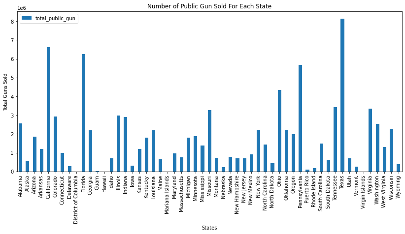

```python
# First lets get the total guns sold for each state
guns_sold_publicly = df_gun.groupby('state', as_index = False)['total_public_gun'].sum()

# plotting a bar chart for the total guns sold
guns_sold_publicly.plot(x = 'state',
                        y = 'total_public_gun',
                        kind = 'bar',
                        title = 'Number of Public Gun Sold For Each State',
                        figsize = (14,6))
plt.xlabel('States')
plt.ylabel('Total Guns Sold');
```

#### Visualizing the class of guns and quantity sold for each class

There are four classes of gun purchased in this dataset. For us to visualize how the classes compare to each other in terms of the one bought the most by Americans, we would be extracting a new dataset called **gun_class** from our **df_gun** data. Then we would plot a bar chart to visualize the varying quantities that was bought.

> From the bar chart, we could see Americans bought more hand guns.
> - The graph depict the total number of gun class bought by Americans in tens of millions.
> - The x-axis represent the class of gun while the y-axis represent the total number of guns.
> - About 47,000,000 hand guns were bought while about 1.8million represent multiple gun purchase

```python
# lets create a dataframe for the four classes of gun and get the total for each class
col_list = ['handgun', 'long_gun', 'other', 'multiple']
gun_class = df_gun[col_list].sum()
gun_class
```

```
handgun     46911107.0
long_gun    44715858.0
other        1959386.0
multiple     1766819.0
dtype: float64
```

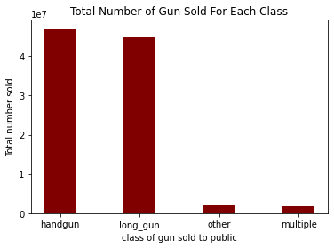

```python
# Plotting a bar chart for the class of gun to see the ones that was sold the most
plt.bar(x=col_list, height=gun_class, width = 0.4, color='maroon')
plt.xlabel('class of gun sold to public')
plt.ylabel('Total number sold')
plt.title('Total Number of Gun Sold For Each Class')
plt.show()
```

#### Lets visualize the trend in the growth of the quantity of guns sold month to month for each year

We would be using a line chart to visualize this. To get this result, we would groupby month and sum the total number of guns sold for that month.

```python
# We would groupby months the total quantity of guns sold
monthly_gun_sold_public = df_gun.groupby('month')['total_public_gun'].sum()
monthly_gun_sold_public
```

```
month
2010-01-01    659977.0
2010-02-01    771696.0
2010-03-01    811824.0
2010-04-01    683484.0
2010-05-01    581825.0
                ...
2017-05-01    926516.0
2017-06-01    947107.0
2017-07-01    845007.0
2017-08-01    950331.0
2017-09-01    939949.0
Name: total_public_gun, Length: 93, dtype: float64
```

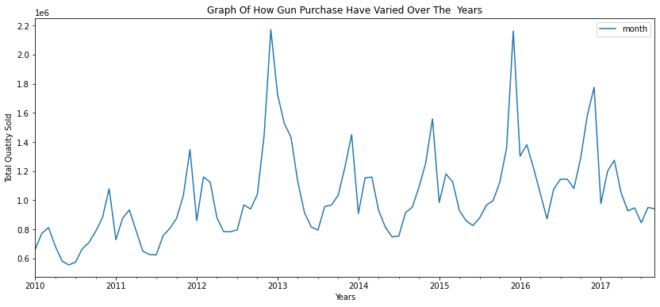

```python
# Plotting a line graph of quantity of guns sold for each month
monthly_gun_sold_public.plot(figsize=(14,6))
plt.xlabel('Years')
plt.ylabel('Total Quatity Sold')
plt.title('Graph Of How Gun Purchase Have Varied Over The  Years')
plt.legend(['month'])
plt.show();
```

### Transformation on the US census data to prepare it for merging

At this stage, we would need to carry out a couple of transformations on both datasets so that we can merge them. All columns would likely not be selected for the new dataset we are about to create.

```python
"""
Creating a new dataset df_census1 with information containing population estimate for 2016 and 2010,
percentage population change, median household income, per capita income and total population in
employment as at 2015
"""
df_census1 = df_census.iloc[[0,1,2,47,48,51]]
df_census1
```

|  | fact | alabama | alaska | arizona | arkansas | california | colorado | connecticut | delaware | florida | ... | south_dakota | tennessee | texas | utah | vermont | virginia | washington | west_virginia | wisconsin | wyoming |
| --- | --- | --- | --- | --- | --- | --- | --- | --- | --- | --- | --- | --- | --- | --- | --- | --- | --- | --- | --- | --- | --- |
| 0 | Population estimates July 1 2016 (V2016) | 4863300.0 | 741894.0 | 6931071.0 | 2988248.0 | 39250017.0 | 5540545.0 | 3576452.0 | 952065.0 | 20612439.0 | ... | 865454.000 | 6651194.000 | 27862596.0 | 3051217.0 | 624594.0 | 8411808.0 | 7288000.0 | 1831102.0 | 5778708.0 | 585501.0 |
| 1 | Population estimates base April 1 2010 (V2016) | 4780131.0 | 710249.0 | 6392301.0 | 2916025.0 | 37254522.0 | 5029324.0 | 3574114.0 | 897936.0 | 18804592.0 | ... | 814195.000 | 6346298.000 | 25146100.0 | 2763888.0 | 625741.0 | 8001041.0 | 6724545.0 | 1853011.0 | 5687289.0 | 563767.0 |
| 2 | Population percent change - April 1 2010 (esti... | 1.7 | 4.5 | 8.4 | 2.5 | 5.4 | 10.2 | 0.1 | 6.0 | 9.6 | ... | 0.063 | 0.048 | 10.8 | 10.4 | -0.2 | 5.1 | 8.4 | -1.2 | 1.6 | 3.9 |
| 47 | Median household income (in 2015 dollars) 2011... | 43623.0 | 72515.0 | 50255.0 | 41371.0 | 61818.0 | 60629.0 | 70331.0 | 60509.0 | 47507.0 | ... | 50957.000 | 45219.000 | 53207.0 | 60727.0 | 55176.0 | 65015.0 | 61062.0 | 41751.0 | 53357.0 | 58840.0 |
| 48 | Per capita income in past 12 months (in 2015 d... | 24091.0 | 33413.0 | 25848.0 | 22798.0 | 30318.0 | 32217.0 | 38803.0 | 30554.0 | 26829.0 | ... | 26747.000 | 25227.000 | 26999.0 | 24686.0 | 29894.0 | 34152.0 | 31762.0 | 23450.0 | 28340.0 | 29803.0 |
| 51 | Total employment 2015 | 1634391.0 | 267999.0 | 2295186.0 | 1003113.0 | 14325377.0 | 2253795.0 | 1503102.0 | 397385.0 | 7777990.0 | ... | 353540.000 | 2507205.000 | 10239710.0 | 1203954.0 | 266363.0 | 3198718.0 | 2602408.0 | 565435.0 | 2503532.0 | 219881.0 |

6 rows × 51 columns

```python
# transpose df_census1 dataset to prepare it for merging with the df_gun dataset
df_census1 = df_census1.transpose()
df_census1.head(2)
```

|  | 0 | 1 | 2 | 47 | 48 | 51 |
| --- | --- | --- | --- | --- | --- | --- |
| fact | Population estimates July 1 2016 (V2016) | Population estimates base April 1 2010 (V2016) | Population percent change - April 1 2010 (esti... | Median household income (in 2015 dollars) 2011... | Per capita income in past 12 months (in 2015 d... | Total employment 2015 |
| alabama | 4863300.0 | 4780131.0 | 1.7 | 43623.0 | 24091.0 | 1634391.0 |

```python
# set the first row as column, to remove 0, 1, 2, 47, 48, 51
df_census1.columns = df_census1.iloc[0]
df_census1 = df_census1[1:]
df_census1.head(2)
```

| fact | Population estimates July 1 2016 (V2016) | Population estimates base April 1 2010 (V2016) | Population percent change - April 1 2010 (estimates base) to July 1 2016 (V2016) | Median household income (in 2015 dollars) 2011-2015 | Per capita income in past 12 months (in 2015 dollars) 2011-2015 | Total employment 2015 |
| --- | --- | --- | --- | --- | --- | --- |
| alabama | 4863300.0 | 4780131.0 | 1.7 | 43623.0 | 24091.0 | 1634391.0 |
| alaska | 741894.0 | 710249.0 | 4.5 | 72515.0 | 33413.0 | 267999.0 |

```python
# resetting the index column
df_census1.reset_index(inplace=True, drop=False)
df_census1.head(1)
```

| fact | index | Population estimates July 1 2016 (V2016) | Population estimates base April 1 2010 (V2016) | Population percent change - April 1 2010 (estimates base) to July 1 2016 (V2016) | Median household income (in 2015 dollars) 2011-2015 | Per capita income in past 12 months (in 2015 dollars) 2011-2015 | Total employment 2015 |
| --- | --- | --- | --- | --- | --- | --- | --- |
| 0 | alabama | 4863300.0 | 4780131.0 | 1.7 | 43623.0 | 24091.0 | 1634391.0 |

```python
#using the rename function earlier defined we would remove spaces and utilize small letters for column names
rename_column(df_census1)
```

```
Index(['index', 'population_estimates_july_1_2016__(v2016)',
       'population_estimates_base_april_1_2010__(v2016)',
       'population_percent_change_-_april_1_2010_(estimates_base)_to_july_1_2016__(v2016)',
       'median_household_income_(in_2015_dollars)_2011-2015',
       'per_capita_income_in_past_12_months_(in_2015_dollars)_2011-2015',
       'total_employment_2015'],
      dtype='object', name='fact')
```

```python
# lets give shorter names to our new column
df_census1.rename(columns={'index':'state',
                  'population_estimates_july_1_2016__(v2016)':'population_estimate2016',
                  'population_estimates_base_april_1_2010__(v2016)':'population_estimate2010',
                  'population_percent_change_-_april_1_2010_(estimates_base)_to_july_1_2016__(v2016)':'population_percent_change',
                  'median_household_income_(in_2015_dollars)_2011-2015':'median_income',
                  'per_capita_income_in_past_12_months_(in_2015_dollars)_2011-2015':'per_capital_income',
                  'total_employment_2015':'total_employment'}, inplace=True)

# lets make 'state' the index of our data frame
#df_census1.set_index('state', inplace = True)
df_census1.head(2)
```

| fact | state | population_estimate2016 | population_estimate2010 | population_percent_change | median_income | per_capital_income | total_employment |
| --- | --- | --- | --- | --- | --- | --- | --- |
| 0 | alabama | 4863300.0 | 4780131.0 | 1.7 | 43623.0 | 24091.0 | 1634391.0 |
| 1 | alaska | 741894.0 | 710249.0 | 4.5 | 72515.0 | 33413.0 | 267999.0 |

```python
# lets get some information on our new dataset
df_census1.info()
```

```
<class 'pandas.core.frame.DataFrame'>
RangeIndex: 50 entries, 0 to 49
Data columns (total 7 columns):
 #   Column                     Non-Null Count  Dtype
---  ------                     --------------  -----
 0   state                      50 non-null     object
 1   population_estimate2016    50 non-null     object
 2   population_estimate2010    50 non-null     object
 3   population_percent_change  50 non-null     object
 4   median_income              50 non-null     object
 5   per_capital_income         50 non-null     object
 6   total_employment           50 non-null     object
dtypes: object(7)
memory usage: 2.9+ KB
```

```python
# We would change the object type to float for most of the columns in our new data set
for i in df_census1.columns:
    if i == 'state':
        pass
    else:
        df_census1[i] = df_census1[i].astype(float)
df_census1.info()
```

```
<class 'pandas.core.frame.DataFrame'>
RangeIndex: 50 entries, 0 to 49
Data columns (total 7 columns):
 #   Column                     Non-Null Count  Dtype
---  ------                     --------------  -----
 0   state                      50 non-null     object
 1   population_estimate2016    50 non-null     float64
 2   population_estimate2010    50 non-null     float64
 3   population_percent_change  50 non-null     float64
 4   median_income              50 non-null     float64
 5   per_capital_income         50 non-null     float64
 6   total_employment           50 non-null     float64
dtypes: float64(6), object(1)
memory usage: 2.9+ KB
```

### Visualizing Population growth for each state of the us census data

Have there been a growth in population between 2010 and 2016? Well, we intend to find out graphically. This we would achieve by creating a new dataframe **df_population** containing the population result for 2010 and 2016. Next, we would plot a side by side bar chart to visualize the changes in population.

> From the below bar chart, we could see there was an increase in population.
> - The x-axis represent the total population in tens of million, while the y-axis represent the states.
> - California and Texas have the highest population. This could be the reason why they have a high gun purchase.
> - Though California have more population than Texas, however, the population growth rate in Texas is more than that of California.

```python
# Lets create a dataframe showing population estimate for 2010 and 2016
df_population = df_census1[['state', 'population_estimate2010', 'population_estimate2016']]
df_population.head(2)
```

| fact | state | population_estimate2010 | population_estimate2016 |
| --- | --- | --- | --- |
| 0 | alabama | 4780131.0 | 4863300.0 |
| 1 | alaska | 710249.0 | 741894.0 |

```python
# Changing index column to state to make yticks labeled as states
df_population.set_index('state', inplace=True)
df_population.head(2)
```

| fact state | population_estimate2010 | population_estimate2016 |
| --- | --- | --- |
| alabama | 4780131.0 | 4863300.0 |
| alaska | 710249.0 | 741894.0 |

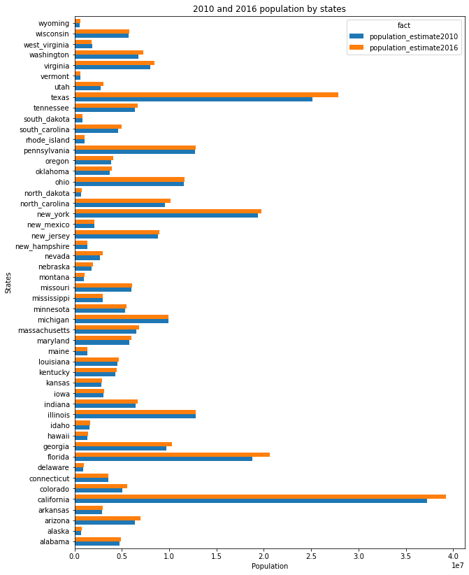

```python
#side by side bar chart for the 2010 and 2017 population of each state
df_population.plot.barh(width=0.8, figsize=(10,14))
plt.title('2010 and 2016 population by states')
plt.xlabel('Population')
plt.ylabel('States')
plt.show()
```

#### Lets extract the class of gun from the gun data set

```python
# Extracting the class of gun
df_gun1 = df_gun.groupby('state', as_index=False)['permit', 'handgun', 'long_gun', 'other', 'multiple', 'total_public_gun'].sum()
df_gun1.head()
```

|  | state | permit | handgun | long_gun | other | multiple | total_public_gun |
| --- | --- | --- | --- | --- | --- | --- | --- |
| 0 | Alabama | 1044693.0 | 1263741.0 | 1191035.0 | 38759.0 | 59764 | 2553299.0 |
| 1 | Alaska | 13315.0 | 261407.0 | 287585.0 | 15504.0 | 16425 | 580921.0 |
| 2 | Arizona | 444644.0 | 1025339.0 | 729000.0 | 55941.0 | 48191 | 1858471.0 |
| 3 | Arkansas | 353334.0 | 518231.0 | 632942.0 | 12829.0 | 31471 | 1195473.0 |
| 4 | California | 4311921.0 | 3245654.0 | 3033764.0 | 342635.0 | 0 | 6622053.0 |

```python
#set the state to index column
df_gun1.set_index('state', inplace=True)
```

```python
# rename the states for df_gun1 so it could match with that of df_census
# replace spaces with underscores and lowercase labels for df_gun1 dataset
df_gun1.rename(index=lambda x: x.strip().lower().replace(" ", "_"), inplace=True)
df_gun1.head()
```

| state | permit | handgun | long_gun | other | multiple | total_public_gun |
| --- | --- | --- | --- | --- | --- | --- |
| alabama | 1044693.0 | 1263741.0 | 1191035.0 | 38759.0 | 59764 | 2553299.0 |
| alaska | 13315.0 | 261407.0 | 287585.0 | 15504.0 | 16425 | 580921.0 |
| arizona | 444644.0 | 1025339.0 | 729000.0 | 55941.0 | 48191 | 1858471.0 |
| arkansas | 353334.0 | 518231.0 | 632942.0 | 12829.0 | 31471 | 1195473.0 |
| california | 4311921.0 | 3245654.0 | 3033764.0 | 342635.0 | 0 | 6622053.0 |

### Merge the df_census1 data with the df_gun1 data

This we would achieve with the pandas merge function. We would be creating a new dataframe **df_gun_census** for this purpose.

```python
# creating a new dataframe by merging the df_gun1 and df_census1 datas
df_gun_census = df_census1.merge(df_gun1, left_on= 'state', right_on= 'state', how='inner')
df_gun_census.head()
```

|  | state | population_estimate2016 | population_estimate2010 | population_percent_change | median_income | per_capital_income | total_employment | permit | handgun | long_gun | other | multiple | total_public_gun |
| --- | --- | --- | --- | --- | --- | --- | --- | --- | --- | --- | --- | --- | --- |
| 0 | alabama | 4863300.0 | 4780131.0 | 1.7 | 43623.0 | 24091.0 | 1634391.0 | 1044693.0 | 1263741.0 | 1191035.0 | 38759.0 | 59764 | 2553299.0 |
| 1 | alaska | 741894.0 | 710249.0 | 4.5 | 72515.0 | 33413.0 | 267999.0 | 13315.0 | 261407.0 | 287585.0 | 15504.0 | 16425 | 580921.0 |
| 2 | arizona | 6931071.0 | 6392301.0 | 8.4 | 50255.0 | 25848.0 | 2295186.0 | 444644.0 | 1025339.0 | 729000.0 | 55941.0 | 48191 | 1858471.0 |
| 3 | arkansas | 2988248.0 | 2916025.0 | 2.5 | 41371.0 | 22798.0 | 1003113.0 | 353334.0 | 518231.0 | 632942.0 | 12829.0 | 31471 | 1195473.0 |
| 4 | california | 39250017.0 | 37254522.0 | 5.4 | 61818.0 | 30318.0 | 14325377.0 | 4311921.0 | 3245654.0 | 3033764.0 | 342635.0 | 0 | 6622053.0 |

### Lets create a function to visualize relationship between variables using seaborn joint plot

```python
def joint_plot(df, xVar, yVar):
    """
    This is a function to define the relationship between
    two variables using seaborn jointplot
    """
    g = sns.jointplot(x = xVar, y = yVar, data = df, kind = 'reg', line_kws = {'color':'maroon'});

    # tidying up labels for x and y axis
    xVar = xVar.replace('_',' ').title()
    yVar = yVar.replace('_',' ').title()

    # add main title to the plot
    plt.suptitle(f"Relationship between {yVar} and {xVar}".title(), weight = 'bold', y=1.04);

    # set axis labels
    g.set_axis_labels(xVar, yVar)

    # set the fig size
    g.fig.set_size_inches(14,6);
```

#### Relationship between population estimate and the total gun sold publicly

We would be using seaborn to visualize this relationship.

> From the diagram below, we could see a positive relationship between the population estimate in 2016 and the total gun likely to be purchased.
> - The x-axis represent population estimate in 2016 in 10millions while the y-axis represent the total gun purchase in 10millions also.
> - The population is not uniformly distributed: There are more states with low population as compared to the number of states with high population.
> - The number of guns bought by states with high population are obviously more.

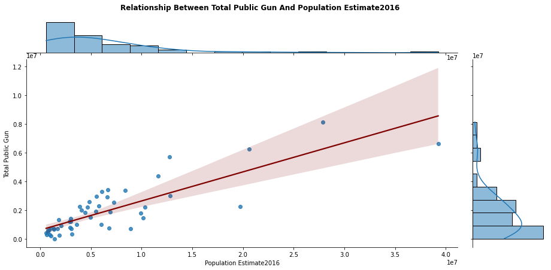

```python
# Lets see the relationship between population estimate and total public gun sold
joint_plot(df_gun_census, 'population_estimate2016', 'total_public_gun')
```

#### Relationship between total employment and the total gun sold publicly

We would be using seaborn to visualize this relationship.

> From the diagram below, we could see that the more people are employed, the more they are likely to purchase a gun.
> - The x-axis of the graph represent the total population of people that are gainfully employed in each state while the y-axis represent the total number of gun purchase.
> - Both the population and the total number of gun purchase are in 10millions.

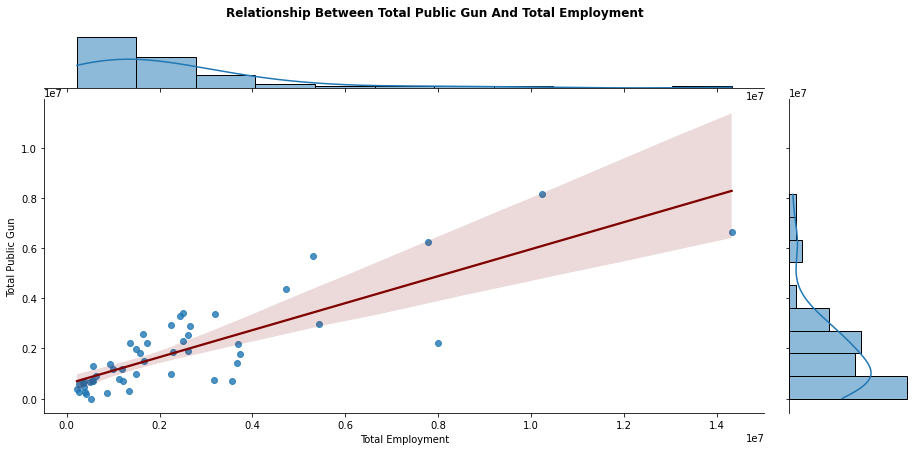

```python
# Lets visualize the relationship between total employment and total public gun sold
joint_plot(df_gun_census, 'total_employment', 'total_public_gun')
```

#### Relationship between per capital income and the total gun sold publicly

We would be using seaborn to visualize this relationship.

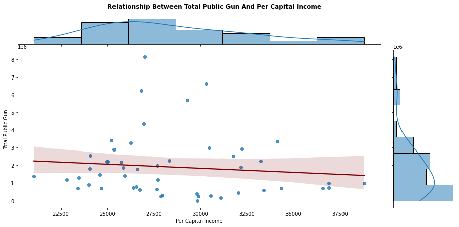

```python
# Lets visualize the relationship between per-capital income and total public gun sold
joint_plot(df_gun_census, 'per_capital_income', 'total_public_gun')
```

#### Visualizing selected variables using box plot

We would be visualizing the following variables using a box plot: `total public gun`, `per capital income`, `population estimate 2016`, `population percent change`. Seaborn would be our tool for this visualization.

> From the box plot, we could observe that the variable is not uniformly distributed. There are outliers in the population estimate and the total gun sold publicly.

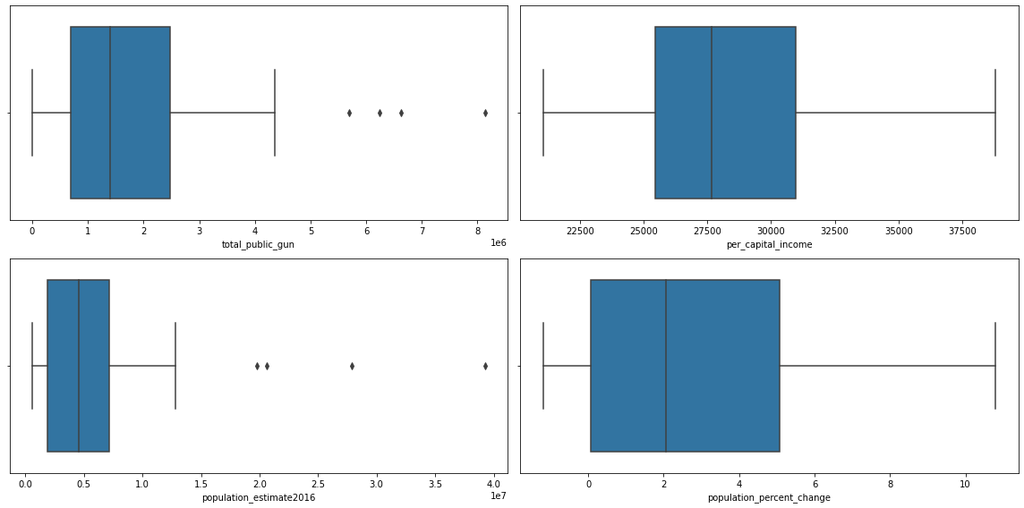

```python
# plotting the box plot for the 4variables mentioned
plt.rcParams["figure.figsize"] = [16.00, 8.00]
plt.rcParams["figure.autolayout"] = True
f, axes = plt.subplots(2, 2)
sns.boxplot(df_gun_census['total_public_gun'], ax=axes[0,0])
sns.boxplot(df_gun_census['per_capital_income'], ax=axes[0,1])
sns.boxplot(df_gun_census['population_estimate2016'], ax=axes[1,0])
sns.boxplot(df_gun_census['population_percent_change'], ax=axes[1,1]);
```

#### Visualizing population estimate and total public gun sold using a histogram

The histogram of the two variables would be ploted side by side using matplotlib.

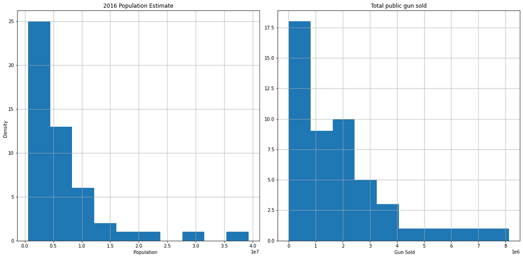

```python
fig, axes = plt.subplots(1,2)
df_gun_census['population_estimate2016'].hist(label='population_estimate2016', ax=axes[0])
df_gun_census['total_public_gun'].hist(label='total_public_gun', ax=axes[1])
axes[0].set_title('2016 Population Estimate')
axes[1].set_title('Total public gun sold')
fig.text(0.25, 0.02, 'Population')
fig.text(0.75, 0.02, 'Gun Sold')
fig.text(0.0, 0.5, 'Density', va='center', rotation='vertical');
```

# DRAW CONCLUSIONS

#### What census data is associated with high census per capital?

To get the census data associated with high census per capital, We would need to classify the combined dataset (df_gun_census) into high, mid_high, mid and low using the per_capital_income column. Then visualize these classes with a barchart to have a good insight of the various classes.

> The graph below, reveals that high income earners are the least likely to buy a gun from public domain.
> - The x-axis of the graph represent income levels while the y-axis represent the total number of guns purchased/per-capital income.
> - On the x-axis, we have the blue bar representing per-capital income and the orange bar representing the total gun purchase in relation to income level.

```python
# Lets get the statistical detail of the per capital income column
df_gun_census['per_capital_income'].describe()
```

```
count       50.000000
mean     28491.780000
std       4103.284534
min      21057.000000
25%      25443.750000
50%      27669.500000
75%      30977.000000
max      38803.000000
Name: per_capital_income, dtype: float64
```

```python
# creating a categorical variable data of high, mid, low per_capital_income
# We would create a new column named income_level for the categorical variables
bin_edges = [21057, 25443.75, 27669.50, 30977.00, 38803.00] #increasing bin monotolitically
bin_names = ['low', 'mid', 'mid_high', 'high']
df_gun_census['income_level'] = pd.cut(df_gun_census['per_capital_income'], bin_edges, labels=bin_names)

df_gun_census.head(3)
```

|  | state | population_estimate2016 | population_estimate2010 | population_percent_change | median_income | per_capital_income | total_employment | permit | handgun | long_gun | other | multiple | total_public_gun | income_level |
| --- | --- | --- | --- | --- | --- | --- | --- | --- | --- | --- | --- | --- | --- | --- |
| 0 | alabama | 4863300.0 | 4780131.0 | 1.7 | 43623.0 | 24091.0 | 1634391.0 | 1044693.0 | 1263741.0 | 1191035.0 | 38759.0 | 59764 | 2553299.0 | low |
| 1 | alaska | 741894.0 | 710249.0 | 4.5 | 72515.0 | 33413.0 | 267999.0 | 13315.0 | 261407.0 | 287585.0 | 15504.0 | 16425 | 580921.0 | high |
| 2 | arizona | 6931071.0 | 6392301.0 | 8.4 | 50255.0 | 25848.0 | 2295186.0 | 444644.0 | 1025339.0 | 729000.0 | 55941.0 | 48191 | 1858471.0 | mid |

```python
# Lets find out how income level affects buying a gun publicly.
df_income_level = df_gun_census.groupby('income_level', as_index=False)['per_capital_income', 'total_public_gun'].sum()
df_income_level
```

|  | income_level | per_capital_income | total_public_gun |
| --- | --- | --- | --- |
| 0 | low | 291689.0 | 21398829.0 |
| 1 | mid | 318476.0 | 32017373.0 |
| 2 | mid_high | 349738.0 | 22188105.0 |
| 3 | high | 443629.0 | 18232357.0 |

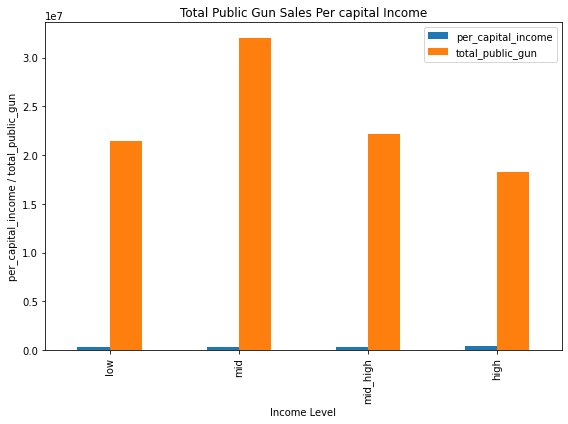

```python
# Lets plot a bar chart to see the income levels of gun buyers from a public source
df_income_level.plot(x= 'income_level', kind='bar', figsize=(8,6), title= 'Total Public Gun Sales Per capital Income')
plt.xlabel('Income Level')
plt.ylabel('per_capital_income / total_public_gun');
```

#### Which state have had the highest growth in gun registration?

To answer this question, we have to query the permit column to get the total permit issued for each state on the first month of our df_gun dataset and also the total permit issued on the last month. The values gotten for each state on the first month would be substracted from that of the last month. The maximum value gotten would indicate the state that has gotten the highest increase in gun registration.

> The state with the highest growth in gun registration is **Kentucky** as shown by the graph below.
> - The horizontal axis represent states while the y-axis represent permit increase.
> - States like Illinoise and Utah have their number of gun registration drop.

```python
# Lets query the data to get all the gun registration done on the first month and group by states
df_permit2010 = df_gun.query("month == '2010-01-01'").groupby('state', as_index=False)['permit'].sum()
df_permit2010.head()
```

|  | state | permit |
| --- | --- | --- |
| 0 | Alabama | 397.0 |
| 1 | Alaska | 0.0 |
| 2 | Arizona | 2211.0 |
| 3 | Arkansas | 1841.0 |
| 4 | California | 24653.0 |

```python
# Lets query the data to get all the gun registration done on the last month and group by states
df_permit2017 = df_gun.query("month == '2017-09-01'").groupby('state', as_index=False)['permit'].sum()
df_permit2017.head()
```

|  | state | permit |
| --- | --- | --- |
| 0 | Alabama | 16717.0 |
| 1 | Alaska | 209.0 |
| 2 | Arizona | 5069.0 |
| 3 | Arkansas | 2935.0 |
| 4 | California | 57839.0 |

```python
# Next, we merge the first month and the last month data set
df_permit_2010_2017 = df_permit2010.merge(df_permit2017, left_on = 'state', right_on = 'state', how= 'inner')
df_permit_2010_2017.head()
```

|  | state | permit_x | permit_y |
| --- | --- | --- | --- |
| 0 | Alabama | 397.0 | 16717.0 |
| 1 | Alaska | 0.0 | 209.0 |
| 2 | Arizona | 2211.0 | 5069.0 |
| 3 | Arkansas | 1841.0 | 2935.0 |
| 4 | California | 24653.0 | 57839.0 |

```python
# subtract permit_x from permit_y to get the increase in gun registration
df_permit_2010_2017['permit_increase'] = df_permit_2010_2017['permit_y'] - df_permit_2010_2017['permit_x']
df_permit_2010_2017.head()
```

|  | state | permit_x | permit_y | permit_increase |
| --- | --- | --- | --- | --- |
| 0 | Alabama | 397.0 | 16717.0 | 16320.0 |
| 1 | Alaska | 0.0 | 209.0 | 209.0 |
| 2 | Arizona | 2211.0 | 5069.0 | 2858.0 |
| 3 | Arkansas | 1841.0 | 2935.0 | 1094.0 |
| 4 | California | 24653.0 | 57839.0 | 33186.0 |

```python
# The state with the highest increase in gun registration would be gotten by finding max of permit_increase
df_permit_2010_2017[df_permit_2010_2017.permit_increase == df_permit_2010_2017.permit_increase.max()]
```

|  | state | permit_x | permit_y | permit_increase |
| --- | --- | --- | --- | --- |
| 18 | Kentucky | 183423.0 | 378384.0 | 194961.0 |

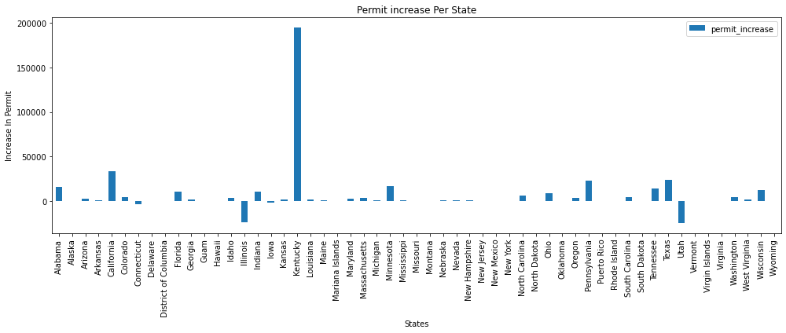

```python
# We can also view the highest increase in gun registration using a bar chart
df_permit_2010_2017.plot(x='state',
                         y='permit_increase',
                         kind='bar', figsize=(14, 6),
                         title= 'Permit increase Per State')

plt.ylabel('Increase In Permit')
plt.xlabel('States');
```

#### What is the overall trend of gun purchases?

The overall trend in gun purchase can be gotten by visualising it through a line chart. The line chart would show the total numbers of guns Americans bought year by year.

```python
# Lets see how the columns of our gun data looks like again
df_gun.head(2)
```

|  | month | state | permit | handgun | long_gun | other | multiple | admin | prepawn_handgun | prepawn_long_gun | prepawn_other | redemption_handgun | redemption_long_gun | redemption_other | totals | total_public_gun |
| --- | --- | --- | --- | --- | --- | --- | --- | --- | --- | --- | --- | --- | --- | --- | --- | --- |
| 0 | 2017-09-01 | Alabama | 16717.0 | 5734.0 | 6320.0 | 221.0 | 317 | 0.0 | 15.0 | 21.0 | 2.0 | 1378.0 | 1262.0 | 1.0 | 31988.0 | 12592.0 |
| 1 | 2017-09-01 | Alaska | 209.0 | 2320.0 | 2930.0 | 219.0 | 160 | 0.0 | 5.0 | 2.0 | 0.0 | 200.0 | 154.0 | 2.0 | 6201.0 | 5629.0 |

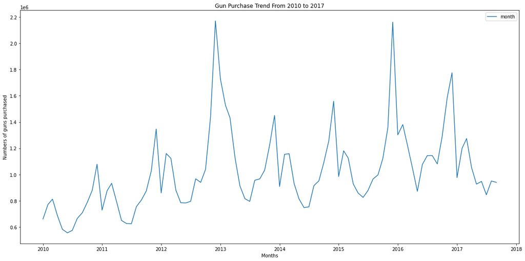

```python
# Lets plots a line graph to show trend in gun purchase over the years
gun_purchase_trend = df_gun.groupby('month')['total_public_gun'].sum()
plt.plot(gun_purchase_trend)
plt.xlabel('Months')
plt.ylabel('Numbers of guns purchased')
plt.title('Gun Purchase Trend From 2010 to 2017')
plt.legend(['month'])
plt.show();
```

#### What are the top five states with high gun sales?

This would be gotten by using a pandas function `nlargest`

```python
# Top five states with the highest gun sales
df_gun_census.nlargest(n=5, columns='total_public_gun')
```

|  | state | population_estimate2016 | population_estimate2010 | population_percent_change | median_income | per_capital_income | total_employment | permit | handgun | long_gun | other | multiple | total_public_gun | income_level |
| --- | --- | --- | --- | --- | --- | --- | --- | --- | --- | --- | --- | --- | --- | --- |
| 42 | texas | 27862596.0 | 25146100.0 | 10.800 | 53207.0 | 26999.0 | 10239710.0 | 1864858.0 | 4077368.0 | 3646992.0 | 190337.0 | 217410 | 8132107.0 | mid |
| 4 | california | 39250017.0 | 37254522.0 | 5.400 | 61818.0 | 30318.0 | 14325377.0 | 4311921.0 | 3245654.0 | 3033764.0 | 342635.0 | 0 | 6622053.0 | mid_high |
| 8 | florida | 20612439.0 | 18804592.0 | 9.600 | 47507.0 | 26829.0 | 7777990.0 | 1088802.0 | 3852411.0 | 2076375.0 | 153326.0 | 159889 | 6242001.0 | mid |
| 37 | pennsylvania | 12784227.0 | 12702857.0 | 0.006 | 53599.0 | 29291.0 | 5306896.0 | 1449305.0 | 2161841.0 | 3515543.0 | 5378.0 | 2802 | 5685564.0 | mid_high |
| 34 | ohio | 11614373.0 | 11536727.0 | 0.007 | 49429.0 | 26953.0 | 4719985.0 | 372278.0 | 2429898.0 | 1714083.0 | 103279.0 | 103273 | 4350533.0 | mid |

#### What are the bottom five states with the least gun sales?

This would be gotten by using a pandas function `nsmallest`

```python
# Bottom five states with the least gun sales
df_gun_census.nsmallest(n=5, columns='total_public_gun')
```

|  | state | population_estimate2016 | population_estimate2010 | population_percent_change | median_income | per_capital_income | total_employment | permit | handgun | long_gun | other | multiple | total_public_gun | income_level |
| --- | --- | --- | --- | --- | --- | --- | --- | --- | --- | --- | --- | --- | --- | --- |
| 10 | hawaii | 1428557.0 | 1360301.0 | 5.000 | 69515.0 | 29822.0 | 523677.0 | 114288.0 | 2.0 | 2.0 | 2.0 | 2 | 8.0 | mid_high |
| 38 | rhode_island | 1056426.0 | 1052940.0 | 0.003 | 56852.0 | 31118.0 | 425748.0 | 0.0 | 86086.0 | 67787.0 | 3852.0 | 12487 | 170212.0 | high |
| 26 | nebraska | 1907116.0 | 1826334.0 | 4.400 | 52997.0 | 27882.0 | 870279.0 | 345249.0 | 10667.0 | 219959.0 | 1461.0 | 432 | 232519.0 | mid_high |
| 44 | vermont | 624594.0 | 625741.0 | -0.200 | 55176.0 | 29894.0 | 266363.0 | 0.0 | 113523.0 | 131185.0 | 4938.0 | 4957 | 254603.0 | mid_high |
| 7 | delaware | 952065.0 | 897936.0 | 6.000 | 60509.0 | 30554.0 | 397385.0 | 22720.0 | 140577.0 | 123606.0 | 5495.0 | 5492 | 275170.0 | mid_high |

# CONCLUSIONS

> **Results**: The following deductions can be made from our data
> - The overall trend in gun purchase has increased over the years with a few spikes in 2013 and 2016
> - `Kentucky` is the state with the highest growth in gun registration with a figure of 194961.0 permits issued
> - High income earners are less likely to purchase a gun publicly, while mid income earners are more likely to purchase a gun from a public source
> - The top five states with the highest number of gun purchase from a public source are `Texas, California, Florida, Pennsylvania, Ohio`
> - The bottom five states with the least number of gun purchase are `Hawaii, Rhode Island, Nebraska, Vermont, Delaware`
> - There is a slight indirect relationship between the total number of gun purchased and per capital income earned. The more the per capital income increases, the more the total number of gun purchased publicly reduces.
> - There is a direct relationship between total employment and total gun purchased

> **Limitations:** These are the limimations we experienced during this analysis
> - We do not have enough informations to draw conclusion on the number of guns bought privately
> - We were not able to create any hypothesis or statistical inferences from our data, because the statistics used are descriptive and not inferential
> - We are working with a sample data, which implies uncertainty (a different sample may lead to different results)
> - There were issues with the sample of data: missing observations, data that appears to be inconsistent